# Project: Investigate TMDB Movie Database

- Introduction
- Data Wrangling
- Exploratory Data Analysis
- Conclusions

## Introduction

In this notebook I plan to study a movie datased named TMDB. As we will see, this dataset includes movie data starting in the 60s and we will analyze it in different steps.

1. First, we will download the dataset and analyse its contents
2. Then, based on our analysis, we will propose some questions to answer
3. At this point, we will use our recent acquired DataFrame skills to answer those questions
4. Finally, we will draw some conclussions on our work

Let´s start doing some standard setup work.

```python
# Import packages that we will use during our investigation
import pandas as pd
import numpy as np
import matplotlib.pyplot as plt
import seaborn as sns
import calendar
%matplotlib inline
```

```python
# Function that we will use during the exercise to decorate our charts
def decorate(title, xlabel, ylabel, xticks=None, xticklabels=None, yticks=None, yticklabels=None):
    #fig, ax = plt.subplots(figsize=(16,9))
    ax.set_title(title, fontsize=22)
    ax.set_xlabel(xlabel)
    ax.set_ylabel(ylabel)
    if xticks is not None:
        ax.set_xticks(xticks)
    if xticklabels is not None:
        ax.set_xticklabels(xticklabels, rotation=70)
    if yticks is not None:
        ax.set_xticks(yticks)
    if yticklabels is not None:
        ax.set_xticklabels(yticklabels, rotation=70)
    ax.grid(alpha=1)
    sns.set(style="dark")
    fig.tight_layout()
```

## Data Wrangling

```python
# Previous to this step we have downloaded the tmdb-movies.csv file from the url provided by Udacity

# Now, we will load the data a DataFrame
df = pd.read_csv('tmdb-movies.csv')
```

```python
# Let´s see the number of rows / columns of our DataFrame
print("Rows:", df.shape[0])
print("Columns:", df.shape[1])
```

```
Rows: 10866
Columns: 21
```

```python
# Take a look at the dataframe content
df.head(5)
```

|  | id | imdb_id | popularity | budget | revenue | original_title | cast | homepage | director | tagline | ... | overview | runtime | genres | production_companies | release_date | vote_count | vote_average | release_year | budget_adj | revenue_adj |
| --- | --- | --- | --- | --- | --- | --- | --- | --- | --- | --- | --- | --- | --- | --- | --- | --- | --- | --- | --- | --- | --- |
| 0 | 135397 | tt0369610 | 32.985763 | 150000000 | 1513528810 | Jurassic World | Chris Pratt\|Bryce Dallas Howard\|Irrfan Khan\|Vi... | http://www.jurassicworld.com/ | Colin Trevorrow | The park is open. | ... | Twenty-two years after the events of Jurassic ... | 124 | Action\|Adventure\|Science Fiction\|Thriller | Universal Studios\|Amblin Entertainment\|Legenda... | 6/9/15 | 5562 | 6.5 | 2015 | 1.379999e+08 | 1.392446e+09 |
| 1 | 76341 | tt1392190 | 28.419936 | 150000000 | 378436354 | Mad Max: Fury Road | Tom Hardy\|Charlize Theron\|Hugh Keays-Byrne\|Nic... | http://www.madmaxmovie.com/ | George Miller | What a Lovely Day. | ... | An apocalyptic story set in the furthest reach... | 120 | Action\|Adventure\|Science Fiction\|Thriller | Village Roadshow Pictures\|Kennedy Miller Produ... | 5/13/15 | 6185 | 7.1 | 2015 | 1.379999e+08 | 3.481613e+08 |
| 2 | 262500 | tt2908446 | 13.112507 | 110000000 | 295238201 | Insurgent | Shailene Woodley\|Theo James\|Kate Winslet\|Ansel... | http://www.thedivergentseries.movie/#insurgent | Robert Schwentke | One Choice Can Destroy You | ... | Beatrice Prior must confront her inner demons ... | 119 | Adventure\|Science Fiction\|Thriller | Summit Entertainment\|Mandeville Films\|Red Wago... | 3/18/15 | 2480 | 6.3 | 2015 | 1.012000e+08 | 2.716190e+08 |
| 3 | 140607 | tt2488496 | 11.173104 | 200000000 | 2068178225 | Star Wars: The Force Awakens | Harrison Ford\|Mark Hamill\|Carrie Fisher\|Adam D... | http://www.starwars.com/films/star-wars-episod... | J.J. Abrams | Every generation has a story. | ... | Thirty years after defeating the Galactic Empi... | 136 | Action\|Adventure\|Science Fiction\|Fantasy | Lucasfilm\|Truenorth Productions\|Bad Robot | 12/15/15 | 5292 | 7.5 | 2015 | 1.839999e+08 | 1.902723e+09 |
| 4 | 168259 | tt2820852 | 9.335014 | 190000000 | 1506249360 | Furious 7 | Vin Diesel\|Paul Walker\|Jason Statham\|Michelle ... | http://www.furious7.com/ | James Wan | Vengeance Hits Home | ... | Deckard Shaw seeks revenge against Dominic Tor... | 137 | Action\|Crime\|Thriller | Universal Pictures\|Original Film\|Media Rights ... | 4/1/15 | 2947 | 7.3 | 2015 | 1.747999e+08 | 1.385749e+09 |

5 rows × 21 columns

```python
# View the number of non null registries and the types of the columns
df.info()
```

```
<class 'pandas.core.frame.DataFrame'>
RangeIndex: 10866 entries, 0 to 10865
Data columns (total 21 columns):
id                      10866 non-null int64
imdb_id                 10856 non-null object
popularity              10866 non-null float64
budget                  10866 non-null int64
revenue                 10866 non-null int64
original_title          10866 non-null object
cast                    10790 non-null object
homepage                2936 non-null object
director                10822 non-null object
tagline                 8042 non-null object
keywords                9373 non-null object
overview                10862 non-null object
runtime                 10866 non-null int64
genres                  10843 non-null object
production_companies    9836 non-null object
release_date            10866 non-null object
vote_count              10866 non-null int64
vote_average            10866 non-null float64
release_year            10866 non-null int64
budget_adj              10866 non-null float64
revenue_adj             10866 non-null float64
dtypes: float64(4), int64(6), object(11)
memory usage: 1.7+ MB
```

```python
df.describe()
```

|  | id | popularity | budget | revenue | runtime | vote_count | vote_average | release_year | budget_adj | revenue_adj |
| --- | --- | --- | --- | --- | --- | --- | --- | --- | --- | --- |
| count | 10866.000000 | 10866.000000 | 1.086600e+04 | 1.086600e+04 | 10866.000000 | 10866.000000 | 10866.000000 | 10866.000000 | 1.086600e+04 | 1.086600e+04 |
| mean | 66064.177434 | 0.646441 | 1.462570e+07 | 3.982332e+07 | 102.070863 | 217.389748 | 5.974922 | 2001.322658 | 1.755104e+07 | 5.136436e+07 |
| std | 92130.136561 | 1.000185 | 3.091321e+07 | 1.170035e+08 | 31.381405 | 575.619058 | 0.935142 | 12.812941 | 3.430616e+07 | 1.446325e+08 |
| min | 5.000000 | 0.000065 | 0.000000e+00 | 0.000000e+00 | 0.000000 | 10.000000 | 1.500000 | 1960.000000 | 0.000000e+00 | 0.000000e+00 |
| 25% | 10596.250000 | 0.207583 | 0.000000e+00 | 0.000000e+00 | 90.000000 | 17.000000 | 5.400000 | 1995.000000 | 0.000000e+00 | 0.000000e+00 |
| 50% | 20669.000000 | 0.383856 | 0.000000e+00 | 0.000000e+00 | 99.000000 | 38.000000 | 6.000000 | 2006.000000 | 0.000000e+00 | 0.000000e+00 |
| 75% | 75610.000000 | 0.713817 | 1.500000e+07 | 2.400000e+07 | 111.000000 | 145.750000 | 6.600000 | 2011.000000 | 2.085325e+07 | 3.369710e+07 |
| max | 417859.000000 | 32.985763 | 4.250000e+08 | 2.781506e+09 | 900.000000 | 9767.000000 | 9.200000 | 2015.000000 | 4.250000e+08 | 2.827124e+09 |

Looking at the describe command, we noticed that the popularity score has a mean value of 0.646 but a max value of 32, which seems a bit strange. Searching the web, we´ve found the way it is calculated and seems that is based in certain user actions like voting over a film or favoriting it (https://developers.themoviedb.org/3/getting-started/popularity).

Being that the case, we have the hypothesis that some films with a huge fan base can have a desproportionate popularity scores against the mean. Also, we think that this score should be higher as the time has passed (more people acting on recent films than in older ones). Let´s plot a scatter graph to test our hypothesis.

[figure not shown]

```python
# Plot correlation between popularity and release_year

# Variables
chart_title="Correlation Popularity / Release year"
chart_xlabel="Popularity"
chart_ylabel="Release Year"

# Plot
fig, ax = plt.subplots(figsize=(16,9))
ax = sns.regplot(x=df['release_year'], y=df['popularity'])

# Decorate
decorate(chart_title, chart_xlabel, chart_ylabel)

plt.show;
```

Effectively, it seems that some titles have disproportionate popularity scores and that this score is increasing as the years passed. Later in this exercise will raise some questions to dig a bit on these movies with huge popularity ratings.

```python
# Let´s check for duplicates
df.duplicated().sum()
```

```
1
```

```python
# Only one duplicate, good. Let´s get rid of it
df.drop_duplicates(inplace=True)
df.duplicated().sum()
```

```
0
```

## Questions

After having seen what data we do have, we plan to answer the following questions based on it:

- What are the distributions revenue, budget (both adjusted for inflation) and vote average?
- Which are the top movies by revenue (adjusted for inflation) of all time?
  - Which is the most revenue (inflation adjusted) generating movie by decade?
- How has the market evolved?
  - Has the revenue per movie gone up or down?
  - Is it more profitable to make movies today than in the past?
- Which movie genres are the most interesting from a profit standpoint?
  - Which movie genres generate more revenue?
  - What are the most profitable genres?
  - Which is the average profit per genre / movie?
- Which are the top revenue generating actors?
- Which are the top revenue generating directors?
- Which are the movies with a higher popularity score?
  - Is there any correlation between Popularity and Vote Average?
- Which is the best month to release a movie?
  - Number of movie releases by month
  - Revenue (adjusted) by month
  - Comparing number of releases with revenue
- Correlation questions
  - Are the budget and revenue correlated?
  - Is there any correlation between revenue and runtime?
  - Is there any correlation between popularity and revenue?
  - Can we find any correlation for profit?

## Data cleaning

After having set our questions to ask, we will clean our DataFrame so we can work more effectively with it.

```python
# First, we will drop columns that we won´t use to answer the questions
df.drop(['id', 'imdb_id', 'homepage', 'tagline', 'keywords', 'overview', 'production_companies'], axis=1, inplace=True)
```

```python
# Then, we will transform the column release date to a datetime format as that will make it easier to work with it
df['release_date'] = pd.to_datetime(df['release_date'])
df.info()
```

```
<class 'pandas.core.frame.DataFrame'>
Int64Index: 10865 entries, 0 to 10865
Data columns (total 14 columns):
popularity        10865 non-null float64
budget            10865 non-null int64
revenue           10865 non-null int64
original_title    10865 non-null object
cast              10789 non-null object
director          10821 non-null object
runtime           10865 non-null int64
genres            10842 non-null object
release_date      10865 non-null datetime64[ns]
vote_count        10865 non-null int64
vote_average      10865 non-null float64
release_year      10865 non-null int64
budget_adj        10865 non-null float64
revenue_adj       10865 non-null float64
dtypes: datetime64[ns](1), float64(4), int64(5), object(4)
memory usage: 1.2+ MB
```

In our resultant DataFrame, we can see that there are some null values in the cast, director and genres columns. Let´s drop those null results now as some of our questions will need to work with those columns.

```python
# Remove rows with nulls on cast, director and genres columns
df = df.dropna(subset=['cast'], axis=0)
df = df.dropna(subset=['director'], axis=0)
df = df.dropna(subset=['genres'], axis=0)
df.info()
```

```
<class 'pandas.core.frame.DataFrame'>
Int64Index: 10731 entries, 0 to 10865
Data columns (total 14 columns):
popularity        10731 non-null float64
budget            10731 non-null int64
revenue           10731 non-null int64
original_title    10731 non-null object
cast              10731 non-null object
director          10731 non-null object
runtime           10731 non-null int64
genres            10731 non-null object
release_date      10731 non-null datetime64[ns]
vote_count        10731 non-null int64
vote_average      10731 non-null float64
release_year      10731 non-null int64
budget_adj        10731 non-null float64
revenue_adj       10731 non-null float64
dtypes: datetime64[ns](1), float64(4), int64(5), object(4)
memory usage: 1.2+ MB
```

## Exploratory Data Analysis

Let´s start answering our questions.

### What are the distributions revenue, budget (both adjusted for inflation) and vote average?

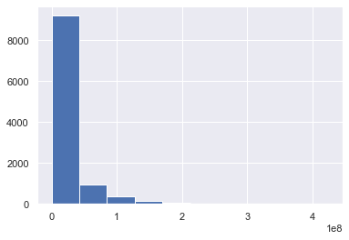

```python
df.budget_adj.hist()
```

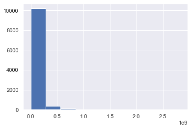

```python
df.revenue_adj.hist()
```

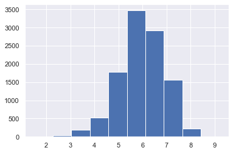

```python
df.vote_average.hist()
```

### Which are the top movies by revenue (adjusted for inflation) of all time?

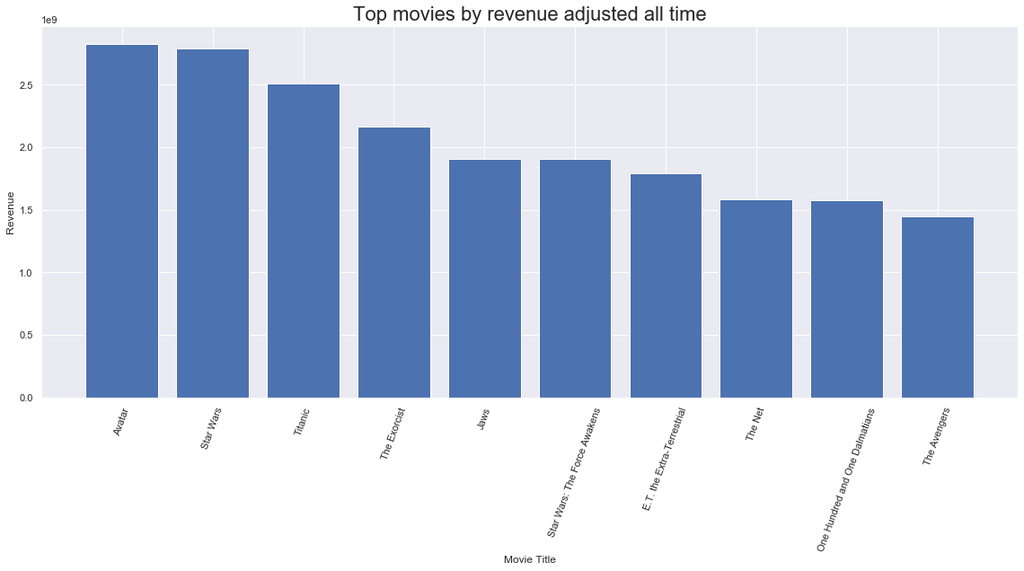

```python
# Create a new dataframe with the top 10 movies by revenue
df_top10 = df.sort_values(by=['revenue_adj'], ascending=False).head(10)

# Plot the results

# Variables
chart_xticks = np.arange(len(df_top10))
chart_xtickslabels = df_top10.original_title
chart_title="Top movies by revenue adjusted all time"
chart_xlabel="Movie Title"
chart_ylabel="Revenue"

# Plot
fig, ax = plt.subplots(figsize=(16,9))
ax.bar(chart_xticks, df_top10.revenue_adj)

# Decorate
decorate(chart_title, chart_xlabel, chart_ylabel, chart_xticks, chart_xtickslabels)

plt.show();
```

### Which is the most revenue (adjusted) generating movie in each decade?

```python
# What is the first and last release year in our datframe
print(df.release_year.min())
print(df.release_year.max())
```

```
1960
2015
```

```python
# Let´s add a column to a new (copied) dataframe with the decade
bin_edges = [1960, 1970, 1980, 1990, 2000, 2010, 2020]
bin_names = ['60s', '70s', '80s', '90s', '00s', '10s']
df_decades = df.copy()
df_decades['decade'] = pd.cut(df_decades['release_year'], bin_edges, labels=bin_names, include_lowest=True)
```

```python
# Get the most rev (adjusted) movie per decade using groupby
grp = df_decades.sort_values(by=['revenue_adj', 'release_year'], ascending=False).groupby(['decade'])

# Create a dataframe from the group results containing the top rev gen movie in each decade
df_top_by_decade = grp.head(1)

# Order the dataframe by decade desc
df_top_by_decade = df_top_by_decade.sort_values('release_year')
```

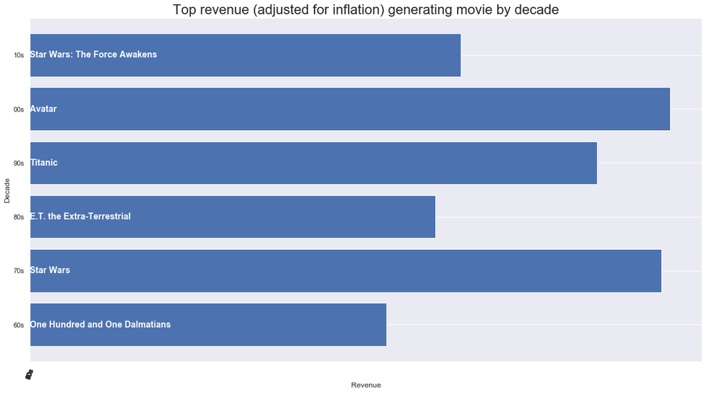

```python
# Plot results

# Variables
y = np.arange(len(df_top_by_decade))
titles = df_top_by_decade.original_title
rev = df_top_by_decade.revenue_adj
decade = df_top_by_decade.decade
chart_title="Top revenue (adjusted for inflation) generating movie by decade"
chart_xlabel="Revenue"
chart_ylabel="Decade"

# Draw the horizontal barchart
fig, ax = plt.subplots(figsize=(16,9))
ax.barh(y, rev, tick_label=decade)

# Decorate the graph
decorate(chart_title, chart_xlabel, chart_ylabel, y, decade)

# Set the title of each movie on each bar
# Source: https://www.machinelearningplus.com/plots/top-50-matplotlib-visualizations-the-master-plots-python/#15.-Ordered-Bar-Chart
for i, val in enumerate(titles):
    ax.text(i, i, val, va='center', fontdict={'fontweight':600, 'size':14, 'color':'white'})

plt.show();
```

### How has the market evolved?

Looking at the top rev generating movies by decade, it doesn´t seem that the recent movies are generating more revenue than previous ones (at least in adjusted dollars terms). Let´s see how the revenue has evolved through the years for our DataFrame.

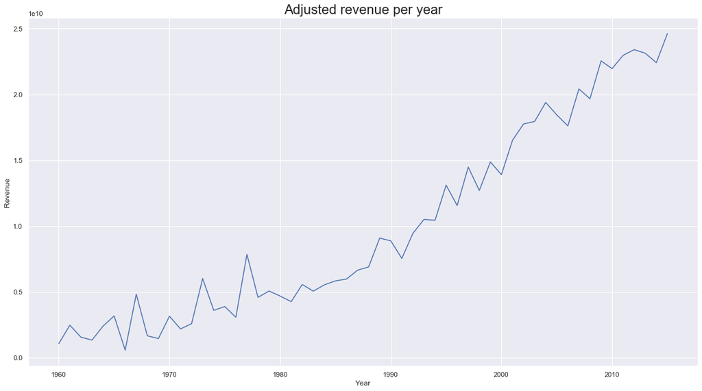

```python
# Get the revenue (adjusted) by year using groupby
df_market = pd.DataFrame(df.groupby(['release_year']).sum().revenue_adj)

# Plot

# Variables
chart_title="Adjusted revenue per year"
chart_xlabel="Year"
chart_ylabel="Revenue"

# Let´s plot a line graph
fig, ax = plt.subplots(figsize=(16,9))
ax.plot(df_market)

# Decorate
decorate(chart_title, chart_xlabel, chart_ylabel)

plt.show();
```

Looking at the graph, we can see how the movie industry revenue has been growing consistently for the last decades, so it seems a good market to be in. However, if the market is doing more movies, the effective revenue per movie could be down, so we need to analyse if this is the case.

```python
movies_per_decade = df_decades.groupby(['decade']).count().original_title
movies_per_decade
```

```
decade
60s     398
70s     543
80s    1108
90s    1852
00s    3776
10s    3054
Name: original_title, dtype: int64
```

Effectively, our data indicates that the market is booming with new films every year, which drives our revenue numbers up. Next, we will study if the effective revenue per movie has go up or down.

### Has the revenue per movie gone up or down?

```python
# Get the number of movies per year
movies_per_year = df.groupby(['release_year']).count().original_title
movies_per_year.head(5)
```

```
release_year
1960    32
1961    31
1962    32
1963    34
1964    42
Name: original_title, dtype: int64
```

```python
# Get the total revenue_adj by year
rev_adj_per_year = df.groupby(['release_year']).revenue_adj.sum()
rev_adj_per_year.head(5)
```

```
release_year
1960    1.069117e+09
1961    2.463622e+09
1962    1.553996e+09
1963    1.334357e+09
1964    2.397193e+09
Name: revenue_adj, dtype: float64
```

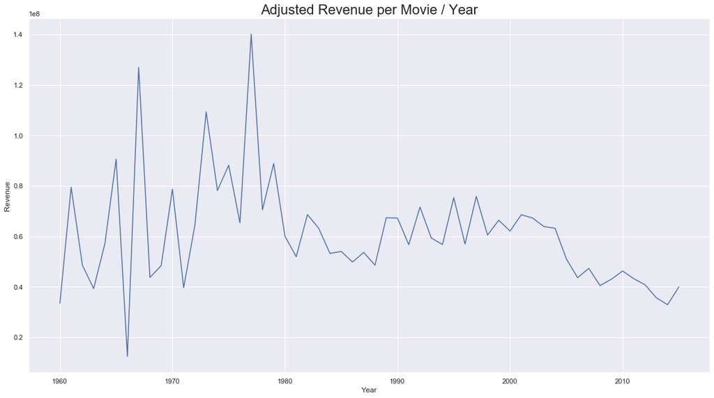

```python
# Get the revenue_adj per movie
rev_per_movie_year = rev_adj_per_year / movies_per_year

# Create a dataframe from the group
df_rev_per_movie_year = pd.DataFrame(rev_per_movie_year)

# Plot

# Variables
chart_title="Adjusted Revenue per Movie / Year"
chart_xlabel="Year"
chart_ylabel="Revenue"

# Plot a line graph
fig, ax = plt.subplots(figsize=(16,9))
ax.plot(df_rev_per_movie_year)

# Decorate
decorate(chart_title, chart_xlabel, chart_ylabel)

plt.show();
```

Interesting. What we can see here is that the average revenue per movie in the last 2 decades is slowing going down. Making movies today seems less profitable than in the previous 50y, but, is this assumption right?

### Is it more profitable to make movies today than in the past?

Until now we´ve been looking just to the revenue adjusted for inflation, but that could be misleading as we can generate a lot of revenue just spending a lot of money. In the following cells we are going to analyze the actual profitability of the market.

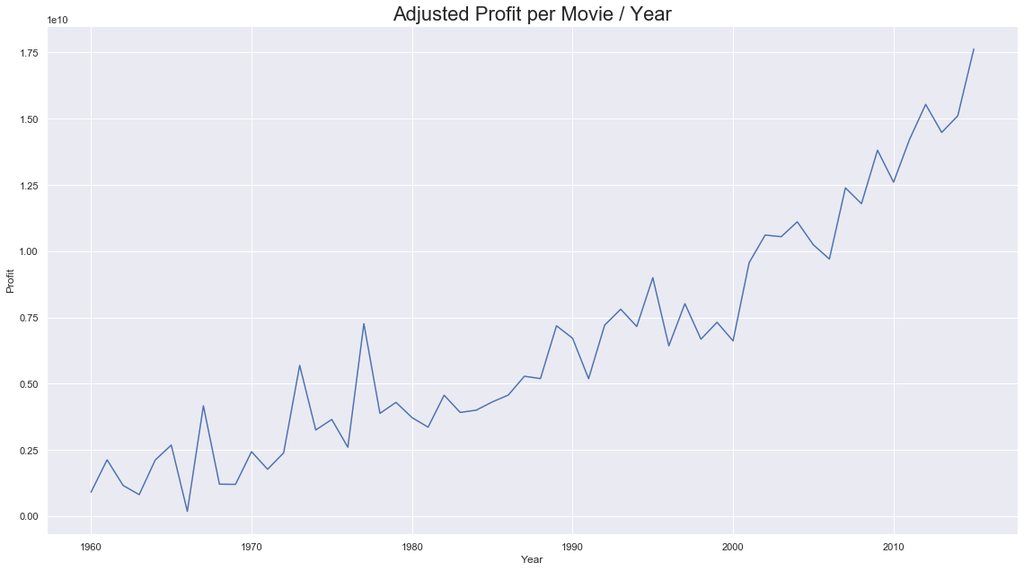

```python
# Get the total revenue_adj by year
rev_adj_per_year = df.groupby(['release_year']).revenue_adj.sum()

# Get the total budget_adj by year
budget_adj_per_year = df.groupby(['release_year']).budget_adj.sum()

# Get the profit per year
profit_per_year = rev_adj_per_year - budget_adj_per_year

# Create a dataframe from the group
df_profit_per_year = pd.DataFrame(profit_per_year)


# Plot

# Variables
chart_title="Adjusted Profit per Movie / Year"
chart_xlabel="Year"
chart_ylabel="Profit"

# Plot a line graph
fig, ax = plt.subplots(figsize=(16,9))
ax.plot(df_profit_per_year)

# Decorate
decorate(chart_title, chart_xlabel, chart_ylabel)

plt.show();
```

As we can see, even with the revenue per movie going down, the profits of movie production have gone up steadily.

### Which movie genres are the most interesting from a profit standpoint?

With this question, we plan to infer, where do we should put our money in the case we wanted to produce a movie.

#### Which movie genres generate more revenue?

```python
# Let´s take a look to the data
df.head(1)
```

|  | popularity | budget | revenue | original_title | cast | director | runtime | genres | release_date | vote_count | vote_average | release_year | budget_adj | revenue_adj |
| --- | --- | --- | --- | --- | --- | --- | --- | --- | --- | --- | --- | --- | --- | --- |
| 0 | 32.985763 | 150000000 | 1513528810 | Jurassic World | Chris Pratt\|Bryce Dallas Howard\|Irrfan Khan\|Vi... | Colin Trevorrow | 124 | Action\|Adventure\|Science Fiction\|Thriller | 2015-06-09 | 5562 | 6.5 | 2015 | 1.379999e+08 | 1.392446e+09 |

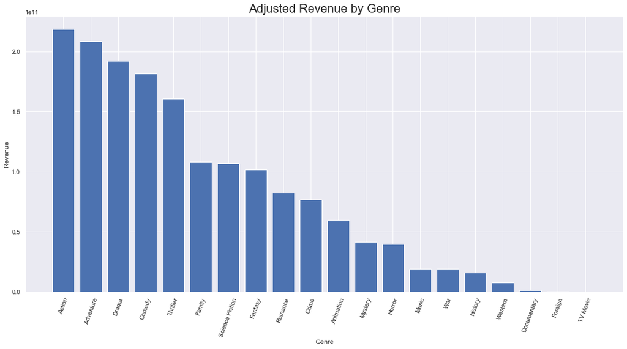

```python
# As we can see, there are several genres in each row, so we will need to split them in order to plot a graph

# To do it, first we create a new df with each genre in its own row
genres = (df.genres.str.split('|', expand=True).stack().to_frame(name='genre'))
genres.index = genres.index.droplevel(1)

# Then, we add the column revenue_adj from the original dataframe and use groupby to group by genre
grp = genres.join(df['revenue_adj']).groupby('genre').sum()

# Finally, we order and plot the results
df_genres_aux = pd.DataFrame(grp.sort_values('revenue_adj', ascending=False))

# Plot a graph

# Variables
chart_title="Adjusted Revenue by Genre"
chart_xlabel="Genre"
chart_ylabel="Revenue"
chart_xticks=np.arange(len(df_genres_aux))
chart_xticklabels=df_genres_aux.index

# Plot a bar graph
fig, ax = plt.subplots(figsize=(16,9))
ax.bar(chart_xticks, df_genres_aux.revenue_adj)

# Decorate
decorate(chart_title, chart_xlabel, chart_ylabel, chart_xticks, chart_xticklabels)

plt.show;
```

As we can see, the genres that generate more revenue are Action, Adventure, Drama, Comedy and Thriller. Will these also be the most profitable ones?

#### What are the most profitable genres?

Knowing wich genres generate more revenue is fine, but we need to look also to the budgets of each one to get a measure of the profitability of them.

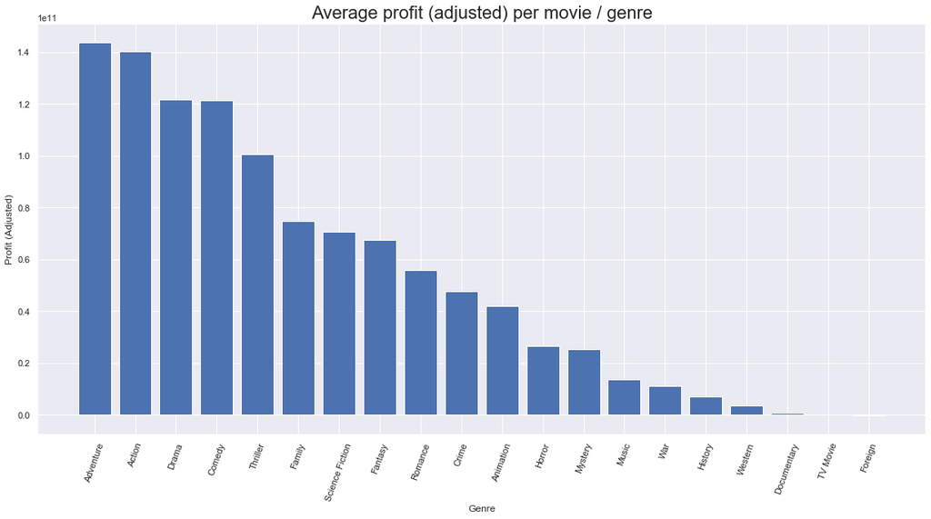

```python
# Split genres (this is not needed as we did it in the previous cell, but I´ll leave it here for readability reasons)
genres = (df.genres.str.split('|', expand=True).stack().to_frame(name='genre'))
genres.index = genres.index.droplevel(1)

# Add revenue_adj column grouped by genre
df_grp = pd.DataFrame(genres.join(df['revenue_adj']).groupby('genre').sum())

# Add budget_adj column grouped by genre
df_grp['budget_adj'] = genres.join(df['budget_adj']).groupby('genre').sum()

# Add profit column
df_grp['profit'] = df_grp['revenue_adj'] - df_grp['budget_adj']

# Sort results
df_genres_aux = pd.DataFrame(df_grp.sort_values('profit', ascending=False))

# Plot

#Variables
chart_title="Average profit (adjusted) per movie / genre"
chart_xlabel="Genre"
chart_ylabel="Profit (Adjusted)"
chart_xticks=np.arange(len(df_genres_aux))
chart_xticklabels=df_genres_aux.index

# Plot a bar graph
fig, ax = plt.subplots(figsize=(16,9))
ax.bar(chart_xticks, df_genres_aux.profit)

# Decorate
decorate(chart_title, chart_xlabel, chart_ylabel, chart_xticks, chart_xticklabels)

plt.show;
```

As we are seeing, the top 5 genres by profitability are the same as the top 5 by revenue. The only difference is that Adventure is more profitable than Action, while Action movies generate more revenue overall.

#### Which is the average profit per genre / movie?

We now know the profit per genre in our DataFrame, but there is still a missing piece and is knowing which is the actual profit per movie. To do that, we are going to create a new dataframe grouped by genre, add a profit and movie count columns and then calculate and plot the average profit per genre / movie.

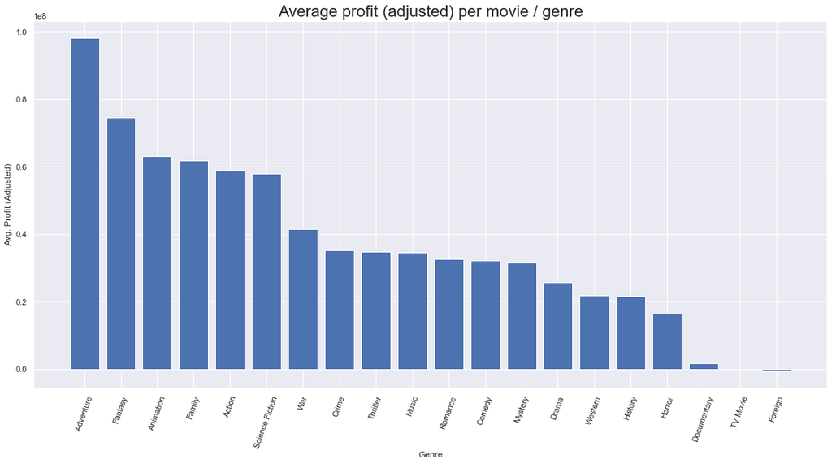

```python
# Split genres (this is not needed as we did it in the previous cell, but I´ll leave it here for readability reasons)
genres = (df.genres.str.split('|', expand=True).stack().to_frame(name='genre'))
genres.index = genres.index.droplevel(1)

# Add revenue_adj column grouped by genre
df_grp = pd.DataFrame(genres.join(df['revenue_adj']).groupby('genre').sum())

# Add budget_adj column grouped by genre
df_grp['budget_adj'] = genres.join(df['budget_adj']).groupby('genre').sum()

# Add a calculated profit per genre column
df_grp['profit'] = df_grp['revenue_adj'] - df_grp['budget_adj']

# Add the count of movies per each genre
df_grp['count'] = genres.join(df).groupby('genre').original_title.count()

# Add one last column with the average profit per movie / genre
df_grp['avg_profit_per_movie'] = df_grp['profit'] / df_grp['count'].astype(float)

# Sort results
df_genres_aux = pd.DataFrame(df_grp.sort_values('avg_profit_per_movie', ascending=False))

# Plot the results

# Variables
chart_title="Average profit (adjusted) per movie / genre"
chart_xlabel="Genre"
chart_ylabel="Avg. Profit (Adjusted)"
chart_xticks=np.arange(len(df_genres_aux))
chart_xticklabels=df_genres_aux.index

# Plot a bar graph
fig, ax = plt.subplots(figsize=(16,9))
ax.bar(chart_xticks, df_genres_aux.avg_profit_per_movie)

# Decorate
decorate(chart_title, chart_xlabel, chart_ylabel, chart_xticks, chart_xticklabels)

plt.show;
```

Now we are seeing some interesting data. Looking at the individual profit per movie, Adventure it is still the most profitable one, but Fantasy, Family and Animation appeared in the Top5. In fact, Thriller, Comedy and Drama went down to the 9th, 12th and 14th position in our list.

### Which are the top revenue generating actors?

```python
# Let´s review our data format
df.head(1)
```

|  | popularity | budget | revenue | original_title | cast | director | runtime | genres | release_date | vote_count | vote_average | release_year | budget_adj | revenue_adj |
| --- | --- | --- | --- | --- | --- | --- | --- | --- | --- | --- | --- | --- | --- | --- |
| 0 | 32.985763 | 150000000 | 1513528810 | Jurassic World | Chris Pratt\|Bryce Dallas Howard\|Irrfan Khan\|Vi... | Colin Trevorrow | 124 | Action\|Adventure\|Science Fiction\|Thriller | 2015-06-09 | 5562 | 6.5 | 2015 | 1.379999e+08 | 1.392446e+09 |

```python
# As with the genres case, there are several actors in each cast row, so we will need to split them
actors = (df.cast.str.split('|', expand=True).stack().to_frame(name='actor'))
actors.index = actors.index.droplevel(1)
actors.head(5)
```

|  | actor |
| --- | --- |
| 0 | Chris Pratt |
| 0 | Bryce Dallas Howard |
| 0 | Irrfan Khan |
| 0 | Vincent D'Onofrio |
| 0 | Nick Robinson |

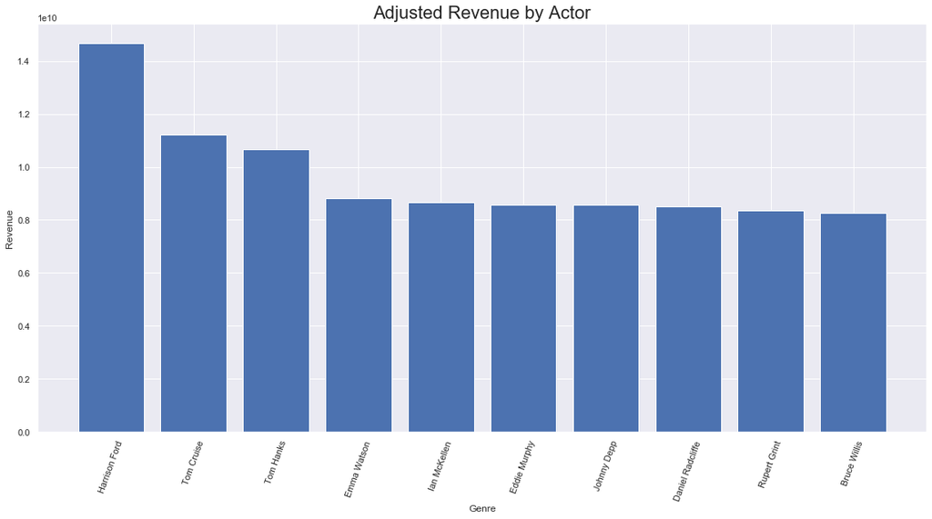

```python
# Add revenue_adj from the original dataframe and use groupby to group by actor
grp = actors.join(df['revenue_adj']).groupby('actor').sum()

# Select the top 10 actors by revenue
df_actors_aux = pd.DataFrame(grp.sort_values('revenue_adj', ascending=False).head(10))

# Plot the results

# Variables
chart_title="Adjusted Revenue by Actor"
chart_xlabel="Genre"
chart_ylabel="Revenue"
chart_xticks=np.arange(len(df_actors_aux))
chart_xticklabels=df_actors_aux.index

# Plot a bar graph
fig, ax = plt.subplots(figsize=(16,9))
ax.bar(chart_xticks, df_actors_aux.revenue_adj)

# Decorate
decorate(chart_title, chart_xlabel, chart_ylabel, chart_xticks, chart_xticklabels)

plt.show;
```

### Which are the top revenue generating directors?

```python
# Let´s review our data format
df.head()
```

|  | popularity | budget | revenue | original_title | cast | director | runtime | genres | release_date | vote_count | vote_average | release_year | budget_adj | revenue_adj |
| --- | --- | --- | --- | --- | --- | --- | --- | --- | --- | --- | --- | --- | --- | --- |
| 0 | 32.985763 | 150000000 | 1513528810 | Jurassic World | Chris Pratt\|Bryce Dallas Howard\|Irrfan Khan\|Vi... | Colin Trevorrow | 124 | Action\|Adventure\|Science Fiction\|Thriller | 2015-06-09 | 5562 | 6.5 | 2015 | 1.379999e+08 | 1.392446e+09 |
| 1 | 28.419936 | 150000000 | 378436354 | Mad Max: Fury Road | Tom Hardy\|Charlize Theron\|Hugh Keays-Byrne\|Nic... | George Miller | 120 | Action\|Adventure\|Science Fiction\|Thriller | 2015-05-13 | 6185 | 7.1 | 2015 | 1.379999e+08 | 3.481613e+08 |
| 2 | 13.112507 | 110000000 | 295238201 | Insurgent | Shailene Woodley\|Theo James\|Kate Winslet\|Ansel... | Robert Schwentke | 119 | Adventure\|Science Fiction\|Thriller | 2015-03-18 | 2480 | 6.3 | 2015 | 1.012000e+08 | 2.716190e+08 |
| 3 | 11.173104 | 200000000 | 2068178225 | Star Wars: The Force Awakens | Harrison Ford\|Mark Hamill\|Carrie Fisher\|Adam D... | J.J. Abrams | 136 | Action\|Adventure\|Science Fiction\|Fantasy | 2015-12-15 | 5292 | 7.5 | 2015 | 1.839999e+08 | 1.902723e+09 |
| 4 | 9.335014 | 190000000 | 1506249360 | Furious 7 | Vin Diesel\|Paul Walker\|Jason Statham\|Michelle ... | James Wan | 137 | Action\|Crime\|Thriller | 2015-04-01 | 2947 | 7.3 | 2015 | 1.747999e+08 | 1.385749e+09 |

It appears that there is one director per row, so we won´t need to split them as we did with the cast column.

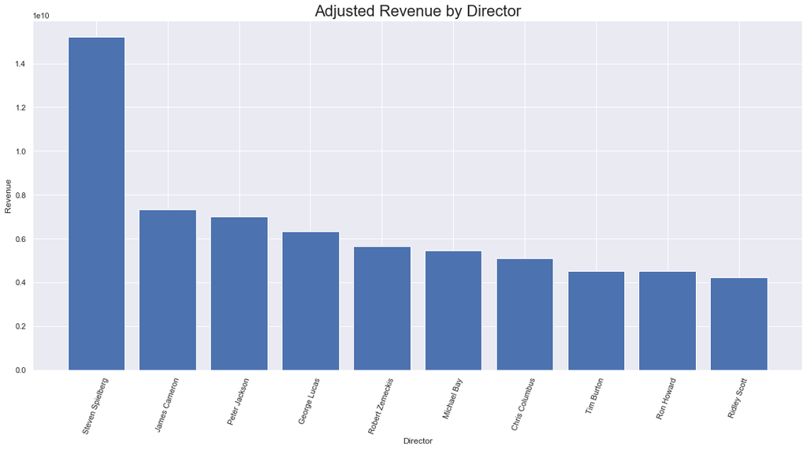

```python
# Add revenue_adj from the original dataframe and use groupby to group by director
df_directors_aux = pd.DataFrame(df.groupby('director').revenue_adj.sum())

# Select the top 10 directors by revenue
df_directors_aux = df_directors_aux.sort_values('revenue_adj', ascending=False).head(10)

# Plot the results

# Variables
chart_title="Adjusted Revenue by Director"
chart_xlabel="Director"
chart_ylabel="Revenue"
chart_xticks=np.arange(len(df_directors_aux))
chart_xticklabels=df_directors_aux.index

# Plot a bar graph
fig, ax = plt.subplots(figsize=(16,9))
ax.bar(chart_xticks, df_directors_aux.revenue_adj)

# Decorate
decorate(chart_title, chart_xlabel, chart_ylabel, chart_xticks, chart_xticklabels)

plt.show;
```

### Which are the movies with the highest popularity score?

Previously in the Data Wrangling section we hypothesized with the popularity score being biased towards recent films with huge fan bases. Let´s see which are the top 10 most popular movies according to popularity to validate our hypothesis.

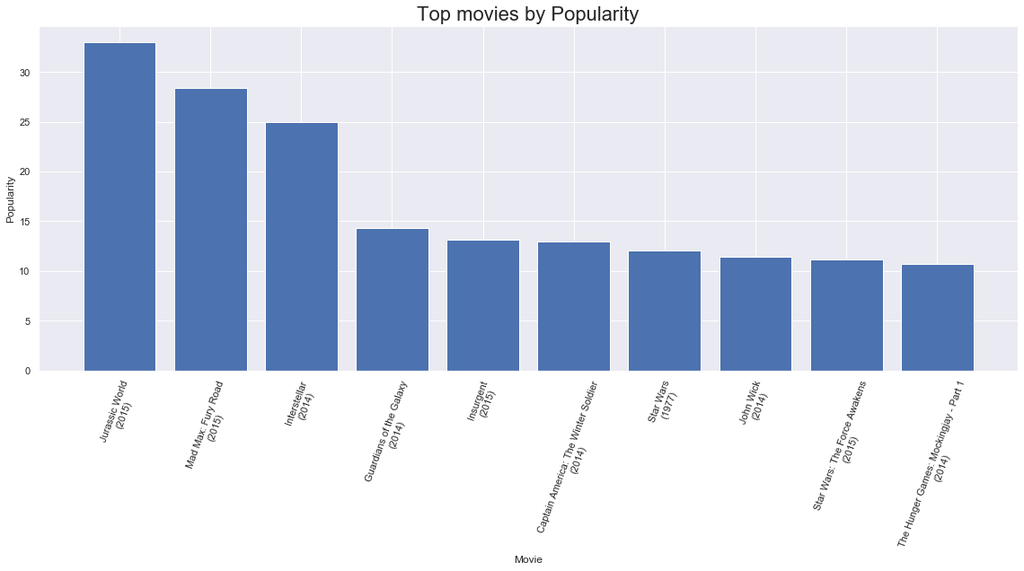

```python
# Create a new dataframe adding a release_month column
df_popularity = pd.DataFrame(df.sort_values('popularity', ascending=False).head(10))

# Plot the results

# Variables
chart_title="Top movies by Popularity"
chart_xlabel="Movie"
chart_ylabel="Popularity"
chart_xticks=np.arange(len(df_popularity))
chart_xticklabels=["{}\n({})".format(x1, x2) for x1, x2, in zip(df_popularity.original_title, df_popularity.release_year)]

# Plot a bar graph
fig, ax = plt.subplots(figsize=(16,9))
ax.bar(chart_xticks, df_popularity.popularity)

# Decorate
decorate(chart_title, chart_xlabel, chart_ylabel, chart_xticks, chart_xticklabels)

plt.show;
```

Looking at the list, it seems evident that a recency is a key factor in the popularity score (9 out of 10 movies were released in the last 2 years of data), and the only other one in the list is Star Wars, which surprises nobody.

### Is there any correlation between Popularity and Vote Average?

We have another measure of popularity in our DataFrame, a Vote Average value between 0 and 10 that represents the score that people have given to each movie. Will it be correlated to the popularity score we´ve just seen. Let´s see to the top movies by this value.

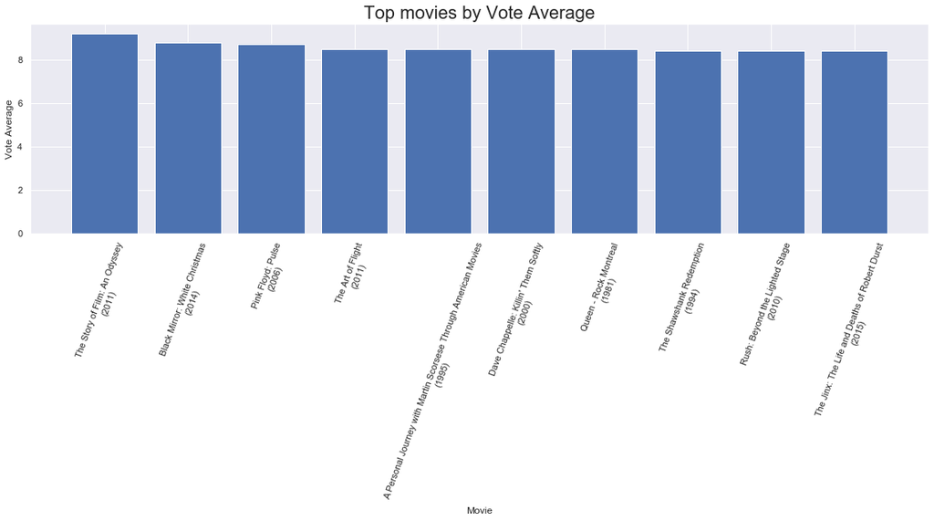

```python
# Create a new dataframe adding a release_month column
df_vote_average = pd.DataFrame(df.sort_values('vote_average', ascending=False).head(10))

# Plot the results

# Variables
chart_title="Top movies by Vote Average"
chart_xlabel="Movie"
chart_ylabel="Vote Average"
chart_xticks=np.arange(len(df_vote_average))
chart_xticklabels=["{}\n({})".format(x1, x2) for x1, x2, in zip(df_vote_average.original_title, df_vote_average.release_year)]

# Plot a bar graph
fig, ax = plt.subplots(figsize=(16,9))
ax.bar(chart_xticks, df_vote_average.vote_average)

# Decorate
decorate(chart_title, chart_xlabel, chart_ylabel, chart_xticks, chart_xticklabels)

plt.show;
```

Well, at a first glance it doesn´t seem that we´ll find a huge correlation, as none of the top 10 films coincide. Let´s plot a correlation chart to check it.

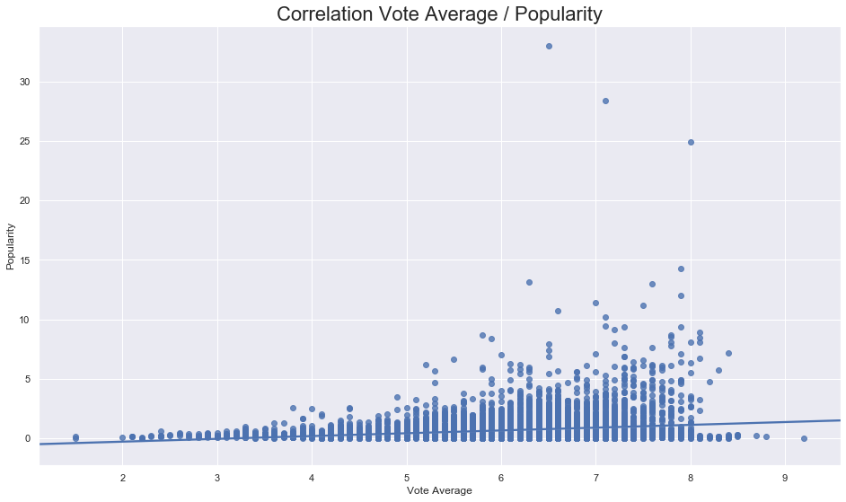

```python
# Variables
chart_title="Correlation Vote Average / Popularity"
chart_xlabel="Vote Average"
chart_ylabel="Popularity"

# Plot
ax = plt.subplots(figsize=(16,9))
ax = sns.regplot(x=df['vote_average'], y=df['popularity'])

# Decorate
decorate(chart_title, chart_xlabel, chart_ylabel)

plt.show;
```

Contrary to our deduction looking at the Top10 charts, we can appreciate certain positive correlation between Popularity and Vote Average. Later in the exercise we will find what is the exact number with a correlation matrix graph.

### Which is the best month to release a movie?

Our next question will be which is the best month to release a movie. To do it, we are going to get the number of releases per month, it´s revenue, and then compare it.

#### Number of movie releases by month

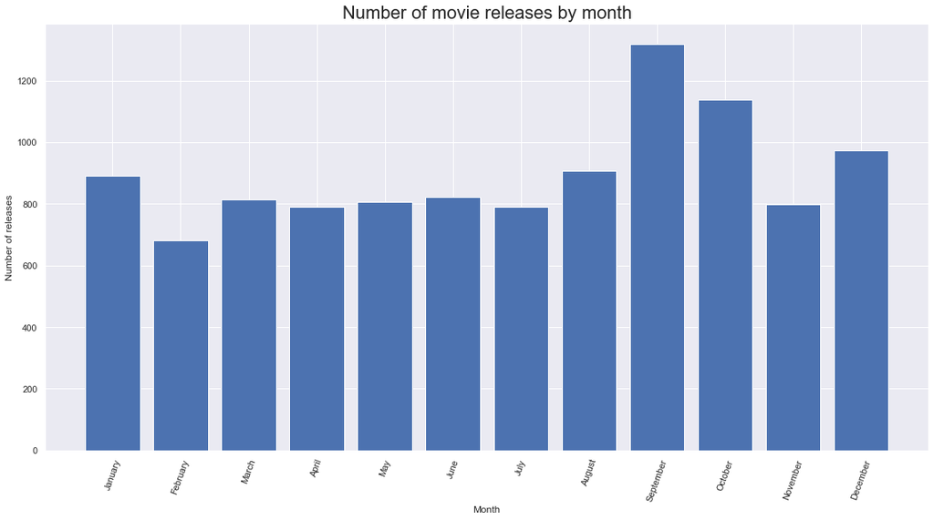

```python
# Create a new dataframe adding a release_month column
df_month = df.copy()
df_month['release_month'] = df['release_date'].dt.month

# Group by month number
df_grp = pd.DataFrame(df_month.groupby('release_month').original_title.count())

# Plot the results

# Variables
chart_title="Number of movie releases by month"
chart_xlabel="Month"
chart_ylabel="Number of releases"
chart_xticks=np.arange(12)
chart_xticklabels=(calendar.month_name[1:13])

# Plot a bar graph
fig, ax = plt.subplots(figsize=(16,9))
ax.bar(chart_xticks, df_grp['original_title'])

# Decorate
decorate(chart_title, chart_xlabel, chart_ylabel, chart_xticks, chart_xticklabels)

plt.show;
```

#### Revenue (adjusted) by month

[figure not shown]

```python
# Group by month number - revenue sum
# grp = df_month.groupby('release_month').revenue_adj.sum()

# Create a new dataframe adding a release_month column
df_month = df.copy()
df_month['release_month'] = df['release_date'].dt.month

# Group by month number
df_grp = pd.DataFrame(df_month.groupby('release_month').revenue_adj.sum())

# Plot the results

# Variables
chart_title="Number of movie releases by month"
chart_xlabel="Month"
chart_ylabel="Revenue (Adjusted)"
chart_xticks=np.arange(12)
chart_xticklabels=(calendar.month_name[1:13])

# Plot a bar graph
fig, ax = plt.subplots(figsize=(16,9))
ax.bar(chart_xticks, df_grp['revenue_adj'])

# Decorate
decorate(chart_title, chart_xlabel, chart_ylabel, chart_xticks, chart_xticklabels)

plt.show;
```

#### Comparing number of releases with revenue

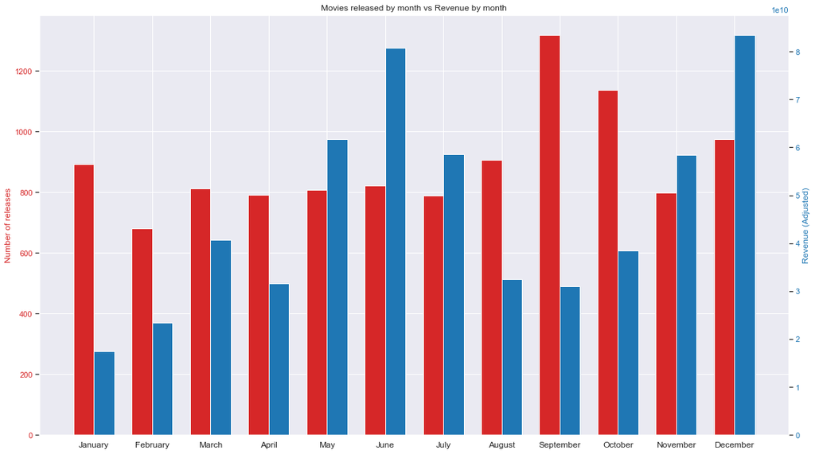

```python
# Let´s add the dataframes for doing it all in one graph
# https://matplotlib.org/3.1.1/gallery/lines_bars_and_markers/barchart.html#sphx-glr-gallery-lines-bars-and-markers-barchart-py
# https://www.machinelearningplus.com/plots/top-50-matplotlib-visualizations-the-master-plots-python/#41.-Plotting-with-different-scales-using-secondary-Y-axis

x = np.arange(12)
y1 = df_month.groupby('release_month').original_title.count()
y2 = df_month.groupby('release_month').revenue_adj.sum()
width = 0.35

# Plot number of releases by month on the left Y axis
fig, ax1 = plt.subplots(1, 1, figsize=(16,9))
ax1.bar(x - width/2, y1, width, color='tab:red')

# Plot the revenue (adjusted) by month on the right Y axix
ax2 = ax1.twinx()
ax2.bar(x + width/2, y2, width, color='tab:blue')

# Decorate
ax1.tick_params(axis='x', rotation=0, labelsize=12)
ax1.set_ylabel('Number of releases', color='tab:red')
ax1.tick_params(axis='y', rotation=0, labelcolor='tab:red' )
ax1.grid(alpha=1)

ax2.set_ylabel("Revenue (Adjusted)", color='tab:blue')
ax2.tick_params(axis='y', labelcolor='tab:blue')
ax2.set_xticks(x)
ax2.set_xticklabels(calendar.month_name[1:13])
ax2.set_title("Movies released by month vs Revenue by month")

sns.set(style="dark")
fig.tight_layout()
plt.show();
```

### Correlation between variables

Following we are going to study the correlation between some variables in our DataFrame. We want to test if there is some correlation between Revenue and Budget, Runtime and Popularity.

#### Is there any correlation between Revenue and Budget (both adjusted for inflation)?

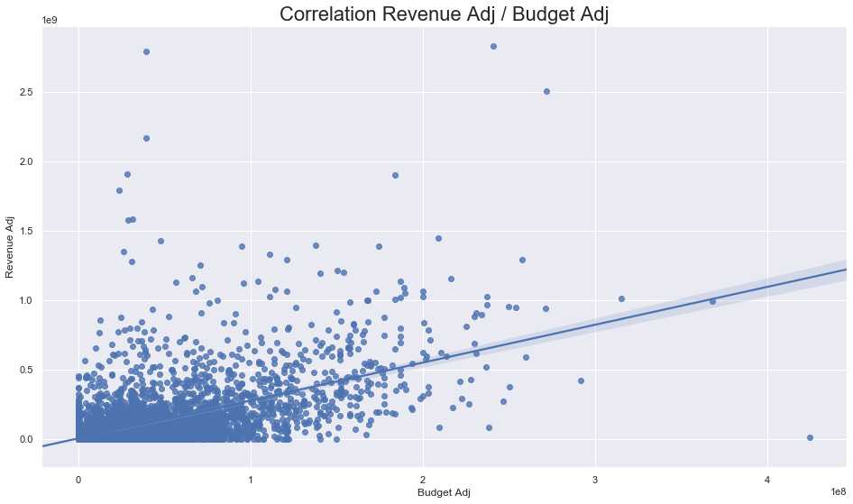

```python
# Variables
chart_title="Correlation Revenue Adj / Budget Adj"
chart_xlabel="Budget Adj"
chart_ylabel="Revenue Adj"

# Plot
ax = plt.subplots(figsize=(16,9))
ax = sns.regplot(x=df['budget_adj'], y=df['revenue_adj'])

# Decorate
decorate(chart_title, chart_xlabel, chart_ylabel)

plt.show;
```

Effectively, we can appreciate as the budget increases, the revenue tends to increase as well.

### Is there any correlation between Revenue and Runtime?

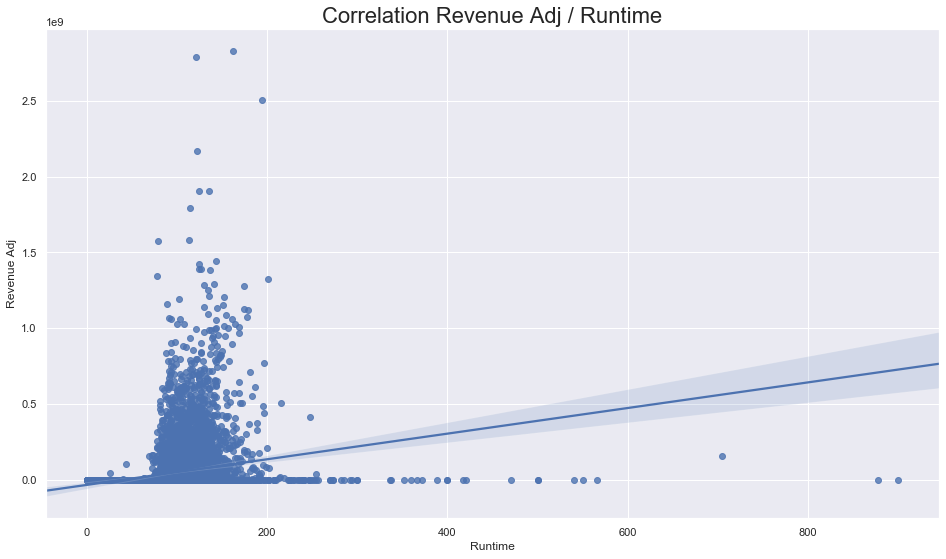

```python
# Variables
chart_title="Correlation Revenue Adj / Runtime"
chart_xlabel="Runtime"
chart_ylabel="Revenue Adj"

# Plot
ax = plt.subplots(figsize=(16,9))
ax = sns.regplot(x=df['runtime'], y=df['revenue_adj'])

# Decorate
decorate(chart_title, chart_xlabel, chart_ylabel)

plt.show;
```

With this graph we can appreciate that there is a weak positive correlation between runtime and revenue, but there are some outliers that maybe we can ignore to get a clearer view. Let´s try it.

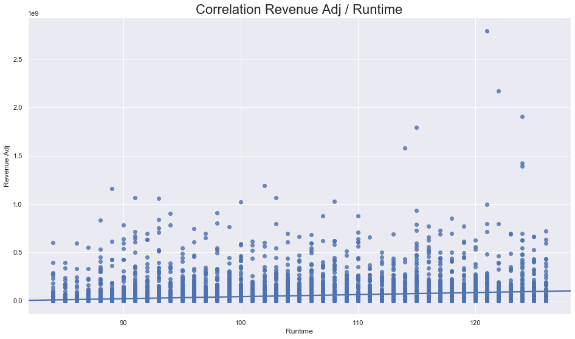

```python
# Create a DataFrame excluding the bottom and top outliers of runtime
df_aux = df.copy()
df_aux = df_aux[df_aux['runtime'] < df_aux.runtime.quantile(0.9)]
df_aux = df_aux[df_aux['runtime'] > df_aux.runtime.quantile(0.1)]

# Variables
chart_title="Correlation Revenue Adj / Runtime"
chart_xlabel="Runtime"
chart_ylabel="Revenue Adj"

# Plot
ax = plt.subplots(figsize=(16,9))
ax = sns.regplot(x=df_aux['runtime'], y=df_aux['revenue_adj'])

# Decorate
decorate(chart_title, chart_xlabel, chart_ylabel)

plt.show;
```

As we thought, in this view without the outliers is easy to appreciate the weak positive correlation between runtime and revenue.

### Is there any correlation between Popularity and Revenue?

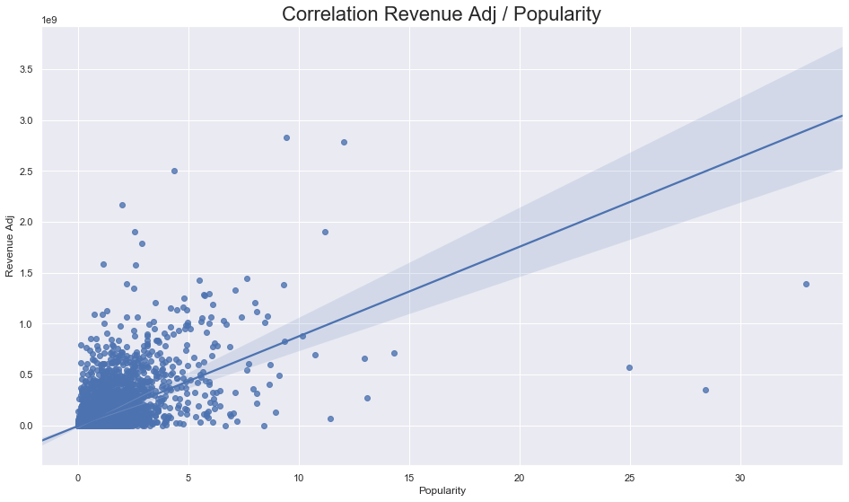

```python
# Variables
chart_title="Correlation Revenue Adj / Popularity"
chart_xlabel="Popularity"
chart_ylabel="Revenue Adj"

# Plot
ax = plt.subplots(figsize=(16,9))
ax = sns.regplot(x=df['popularity'], y=df['revenue_adj'])

# Decorate
decorate(chart_title, chart_xlabel, chart_ylabel)

plt.show;
```

Viewing this chart we can affirm that yes, there is a mid / strong correlation between popularity and revenue.

### Can we find any correlation for profit?

Finally, just for trying another graph method, we are going to try to find what is correlated with profit. We will use the function heatmap from seaborn to get a correlation matrix of all the different variables in our dataframe.

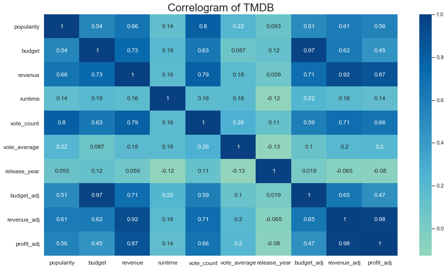

```python
# Create a new dataframe and add a new calculated profit column
df_aux = df.copy()
df_aux['profit_adj'] = df_aux['revenue_adj'] - df_aux['budget_adj']

# Plot
plt.figure(figsize=(16,9))
sns.heatmap(df_aux.corr(), xticklabels=df_aux.corr().columns, yticklabels=df_aux.corr().columns, cmap='GnBu', center=0, annot=True)

# Decorations
plt.title('Correlogram of TMDB', fontsize=22)
plt.xticks(fontsize=12)
plt.yticks(fontsize=12)
plt.show();
```

With this matrix, it´s pretty easy to see that profit is correlated positively, in addition to budget and revenue, with popularity and vote_count. It also has a weak correlation with runtime (as we´ve found previously) and vote_average, and no correlation at all with the release year.

## Conclusions

We can extract some conclussions from our analysis, taking into account that our analysis has been only superficial and any finding here stated should probably tested more thoroughly with better statistics methods. Specially, we need to highlight that any finding related with correlation does not imply causation.

## Resources

During this exercise we´ve used different resources from around the web:

- https://stackoverflow.com/questions/48389751/how-do-i-get-matplotlib-to-order-bar-chart-in-the-same-order-as-my-list
- https://cmdlinetips.com/2019/03/how-to-get-top-n-rows-with-in-each-group-in-pandas/
- https://stackoverflow.com/questions/23415500/pandas-plotting-a-stacked-bar-chart
- https://matplotlib.org/3.1.1/gallery/lines_bars_and_markers/barchart.html#sphx-glr-gallery-lines-bars-and-markers-barchart-py
- https://www.machinelearningplus.com/plots/top-50-matplotlib-visualizations-the-master-plots-python/#41.-Plotting-with-different-scales-using-secondary-Y-axis
- https://stackoverflow.com/questions/29188757/matplotlib-specify-format-of-floats-for-tick-lables
- https://datacarpentry.org/python-socialsci/11-joins/index.html
- https://stackoverflow.com/questions/36415407/i-cant-figure-out-how-to-set-multi-line-xticklabels-when-reading-labels-from-a
- https://stackoverflow.com/questions/23199796/detect-and-exclude-outliers-in-pandas-data-frame